# How Does a Bike-Share Navigate Speedy Success?

### Analysis

We will check the summary of the trip duration.

```r
summary(bikedf_2$trip_duration)
```

```
##    Min. 1st Qu.  Median    Mean 3rd Qu.    Max.
##       1     327     576    1102    1026 3087684
```

We will also compare the mean, median, max, and min trip duration for member and casual riders.

```r
aggregate(bikedf_2$trip_duration ~ bikedf_2$member_casual, FUN = mean) #Compare mean
```

```
##   bikedf_2$member_casual bikedf_2$trip_duration
## 1                 casual              1688.8223
## 2                 member               743.2879
```

```r
aggregate(bikedf_2$trip_duration ~ bikedf_2$member_casual, FUN = median) #Compare median
```

```
##   bikedf_2$member_casual bikedf_2$trip_duration
## 1                 casual                    711
## 2                 member                    511
```

```r
aggregate(bikedf_2$trip_duration ~ bikedf_2$member_casual, FUN = max) #Compare max
```

```
##   bikedf_2$member_casual bikedf_2$trip_duration
## 1                 casual                3087684
## 2                 member                  93580
```

```r
aggregate(bikedf_2$trip_duration ~ bikedf_2$member_casual, FUN = min) #Compare min
```

```
##   bikedf_2$member_casual bikedf_2$trip_duration
## 1                 casual                      1
## 2                 member                      1
```

As we can observe, casual riders have longer mean and median trip duration compared to member riders.

```r
# Order by day of week
bikedf_2$start_day_week <- ordered(bikedf_2$start_day_week,
                                       levels=c("Sunday", "Monday", "Tuesday",
                                                "Wednesday", "Thursday", "Friday",
                                                "Saturday"))

bikedf_2 %>%
  group_by(member_casual, start_day_week) %>%  #group by rider type and by day of the week
  summarise(number_of_rides = n() #calculates the total number of rides
            ,average_trip_duration = mean(trip_duration)) %>% # calculates the average trip duration
  arrange(start_day_week, member_casual) # sorts by day of the week then by rider type
```

```
## # A tibble: 14 × 4
## # Groups:   member_casual [2]
##    member_casual start_day_week number_of_rides average_trip_duration
##    <chr>         <ord>                    <int>                 <dbl>
##  1 casual        Sunday                  332561                 1982.
##  2 member        Sunday                  386470                  821.
##  3 casual        Monday                  257919                 1636.
##  4 member        Monday                  501419                  710.
##  5 casual        Tuesday                 256851                 1509.
##  6 member        Tuesday                 551914                  715.
##  7 casual        Wednesday               262382                 1445.
##  8 member        Wednesday               565860                  707.
##  9 casual        Thursday                289206                 1431.
## 10 member        Thursday                569831                  713.
## 11 casual        Friday                  335077                 1643.
## 12 member        Friday                  516683                  741.
## 13 casual        Saturday                435233                 1955.
## 14 member        Saturday                461485                  832.
```

As we can observe in the above table, members use bikes more than casual riders. However, casual riders use the bikes longer than the member riders on average. We can also observe than casual riders use bikes more during Fridays and during the weekends.

#### Comparing Casual and Member Riders

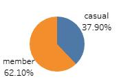

As we can see in the above pie chart, 37.9% of the riders in the data are casual riders, while 62.1% are member riders.

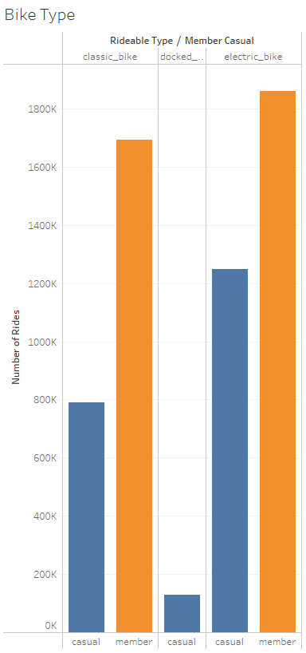

We can see in the above graph that both casual and member riders prefer classic and electric bikes over docked bikes with member riders not using the docked bikes.

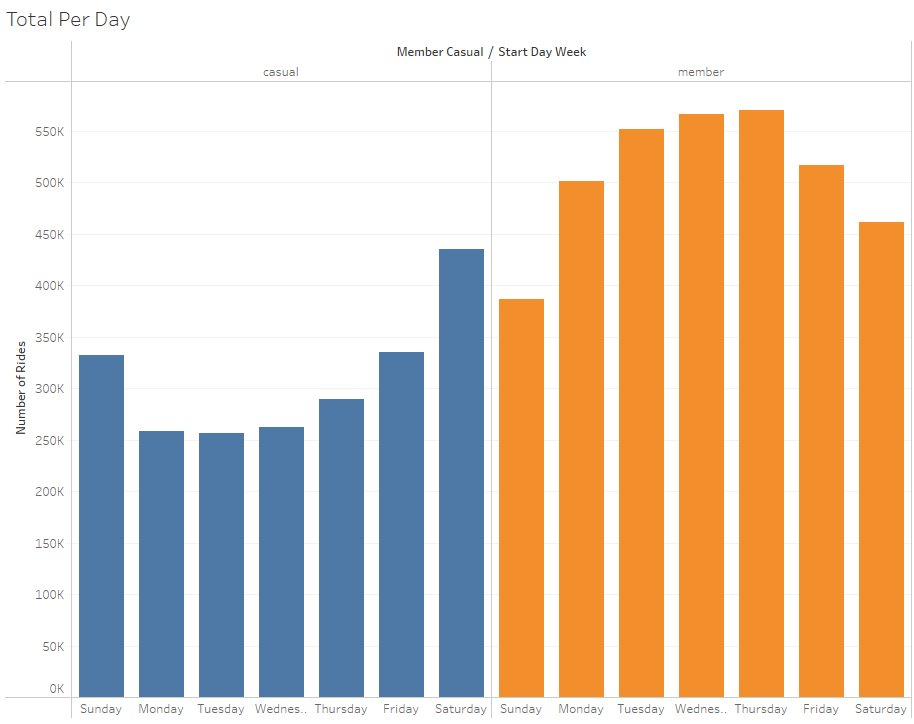

Member riders use bikes more during the weekdays. However, casual riders use bikes more during Fridays and weekends.

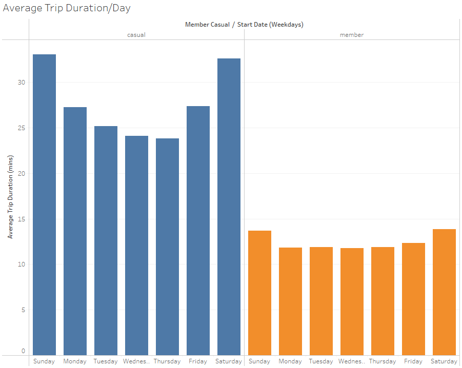

We can see however, that casual riders ride longer compared to member riders.

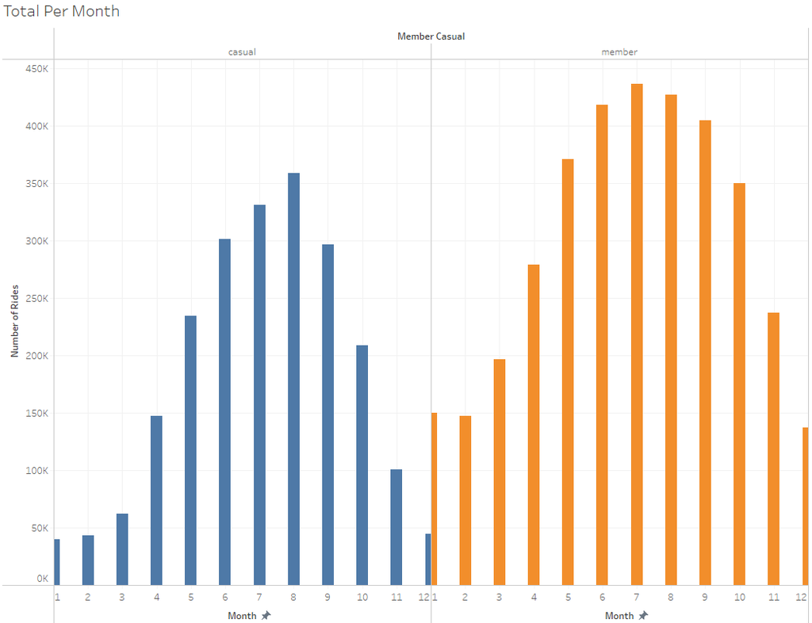

For both rider types, we can see a similar trend where the number of rides peak from the month of June to September and that there are less number of rides for the rest of the year.

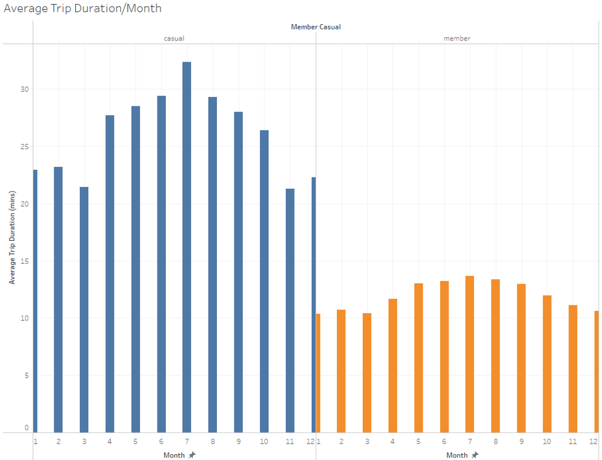

There is also a similar trend to the average trip duration for both casual and member riders. However, casual riders use the bikes longer compared to member riders. Casual riders also ride the longest during the month of July.

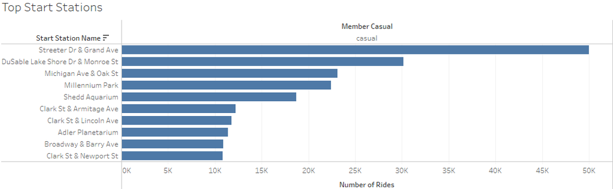

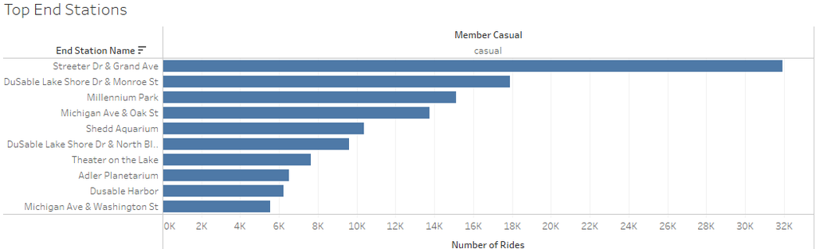

In the above images, we can see the top ten start and end stations for casual riders. The common stations for both start and end stations are the following:

- Streeter Dr & Grand Ave
- DuSable Lake Shore Dr & Monroe St
- Millenium Park
- Michigan Ave & Oak St
- Shedd Aquarium
- Adler Planetarium

We can use this information to set where to focus the advertisements.

### Act

1. Casual riders use the bikes more during Fridays and weekends so it will be best to focus marketing during those days. There are also more casual riders from June up to September, so those will be good months to do promotions.
2. Marketing may also be focused on the top 10 start and end stations so more casual riders will be able to see the promotions. We can also focus only on the 6 common start and end stations.
3. We can also provide offers and discounts to casual riders when they upgrade to members during peak days and/or months.